# Is Automatic or Manual transmission better for MPG?

### Models with selected variables as predictors

Selecting a subset of predictor variables form large set is a controversial topic. Here we perform stepwise selection method and all-subset regression method.

Stepwise selection using stepAIC(), which performs stepwise model selection by exact AIC

```r
library(MASS)
fit_AIC<- stepAIC (fit_m, direction = "both")
```

```
## Start:  AIC=76.4
## mpg ~ cyl + disp + hp + drat + wt + qsec + vs + am + gear + carb
##
##        Df Sum of Sq    RSS    AIC
## - carb  5   13.5989 134.00 69.828
## - gear  2    3.9729 124.38 73.442
## - am    1    1.1420 121.55 74.705
## - qsec  1    1.2413 121.64 74.732
## - drat  1    1.8208 122.22 74.884
## - cyl   2   10.9314 131.33 75.184
## - vs    1    3.6299 124.03 75.354
## <none>              120.40 76.403
## - disp  1    9.9672 130.37 76.948
## - wt    1   25.5541 145.96 80.562
## - hp    1   25.6715 146.07 80.588
##
## Step:  AIC=69.83
## mpg ~ cyl + disp + hp + drat + wt + qsec + vs + am + gear
##
##        Df Sum of Sq    RSS    AIC
## - gear  2    5.0215 139.02 67.005
## - disp  1    0.9934 135.00 68.064
## - drat  1    1.1854 135.19 68.110
## - vs    1    3.6763 137.68 68.694
## - cyl   2   12.5642 146.57 68.696
## - qsec  1    5.2634 139.26 69.061
## <none>              134.00 69.828
## - am    1   11.9255 145.93 70.556
## - wt    1   19.7963 153.80 72.237
## - hp    1   22.7935 156.79 72.855
## + carb  5   13.5989 120.40 76.403
##
## Step:  AIC=67
## mpg ~ cyl + disp + hp + drat + wt + qsec + vs + am
##
##        Df Sum of Sq    RSS    AIC
## - drat  1    0.9672 139.99 65.227
## - cyl   2   10.4247 149.45 65.319
## - disp  1    1.5483 140.57 65.359
## - vs    1    2.1829 141.21 65.503
```

[output cut: 56 more lines]

```
## Step:  AIC=61.65
## mpg ~ cyl + hp + wt + am
##
##        Df Sum of Sq    RSS    AIC
## <none>              151.03 61.655
## - am    1     9.752 160.78 61.657
## + vs    1     7.346 143.68 62.059
## + qsec  1     7.044 143.98 62.126
## - cyl   2    29.265 180.29 63.323
## + disp  1     0.617 150.41 63.524
## + drat  1     0.220 150.81 63.608
## + gear  2     1.361 149.66 65.365
## - hp    1    31.943 182.97 65.794
## - wt    1    46.173 197.20 68.191
## + carb  5     5.633 145.39 70.438
```

```r
fit_AIC$anova
```

```
## Stepwise Model Path
## Analysis of Deviance Table
##
## Initial Model:
## mpg ~ cyl + disp + hp + drat + wt + qsec + vs + am + gear + carb
##
## Final Model:
## mpg ~ cyl + hp + wt + am
##
##
##     Step Df   Deviance Resid. Df Resid. Dev      AIC
## 1                             15   120.4027 76.40339
## 2 - carb  5 13.5988573        20   134.0015 69.82769
## 3 - gear  2  5.0215145        22   139.0230 67.00492
## 4 - drat  1  0.9672159        23   139.9903 65.22678
## 5 - disp  1  1.2473996        24   141.2377 63.51066
## 6 - qsec  1  2.4420033        25   143.6797 62.05921
## 7   - vs  1  7.3459298        26   151.0256 61.65483
```

All-subsets regression Using leaps()

```r
library(leaps)
fit_subsets<-regsubsets(mpg~., data=mydata, nbest=1)
summary(fit_subsets)
```

```
## Subset selection object
## Call: regsubsets.formula(mpg ~ ., data = mydata, nbest = 1)
## 16 Variables  (and intercept)
##       Forced in Forced out
## cyl6      FALSE      FALSE
## cyl8      FALSE      FALSE
## disp      FALSE      FALSE
## hp        FALSE      FALSE
## drat      FALSE      FALSE
## wt        FALSE      FALSE
## qsec      FALSE      FALSE
## vs1       FALSE      FALSE
## am1       FALSE      FALSE
## gear4     FALSE      FALSE
## gear5     FALSE      FALSE
## carb2     FALSE      FALSE
## carb3     FALSE      FALSE
## carb4     FALSE      FALSE
## carb6     FALSE      FALSE
## carb8     FALSE      FALSE
## 1 subsets of each size up to 8
## Selection Algorithm: exhaustive
##          cyl6 cyl8 disp hp  drat wt  qsec vs1 am1 gear4 gear5 carb2 carb3
## 1  ( 1 ) " "  " "  " "  " " " "  "*" " "  " " " " " "   " "   " "   " "
## 2  ( 1 ) " "  " "  " "  "*" " "  "*" " "  " " " " " "   " "   " "   " "
## 3  ( 1 ) " "  " "  " "  " " " "  "*" "*"  " " "*" " "   " "   " "   " "
## 4  ( 1 ) "*"  " "  " "  "*" " "  "*" " "  " " "*" " "   " "   " "   " "
## 5  ( 1 ) "*"  " "  " "  "*" " "  "*" " "  "*" "*" " "   " "   " "   " "
## 6  ( 1 ) "*"  " "  " "  "*" " "  "*" " "  "*" "*" " "   "*"   " "   " "
## 7  ( 1 ) " "  "*"  " "  "*" " "  "*" "*"  "*" "*" " "   "*"   " "   " "
## 8  ( 1 ) "*"  " "  "*"  "*" " "  "*" " "  " " " " "*"   "*"   "*"   " "
##          carb4 carb6 carb8
## 1  ( 1 ) " "   " "   " "
## 2  ( 1 ) " "   " "   " "
## 3  ( 1 ) " "   " "   " "
## 4  ( 1 ) " "   " "   " "
## 5  ( 1 ) " "   " "   " "
## 6  ( 1 ) " "   " "   " "
## 7  ( 1 ) " "   " "   " "
## 8  ( 1 ) " "   " "   "*"
```

## Compairing Models

```r
attach(mydata)
fit1 <-lm(mpg ~ am)
fit2<-lm(mpg ~ wt + am + qsec)
fit3<-lm(mpg ~ wt + hp + am + qsec)
fit4<-lm(mpg ~ ., data = mydata)
anova(fit1, fit2, fit3, fit4)
```

```
## Analysis of Variance Table
##
## Model 1: mpg ~ am
## Model 2: mpg ~ wt + am + qsec
## Model 3: mpg ~ wt + hp + am + qsec
## Model 4: mpg ~ cyl + disp + hp + drat + wt + qsec + vs + am + gear + carb
##   Res.Df    RSS Df Sum of Sq       F    Pr(>F)
## 1     30 720.90
## 2     28 169.29  2    551.61 34.3604 2.509e-06 ***
## 3     27 160.07  1      9.22  1.1486    0.3008
## 4     15 120.40 12     39.66  0.4118    0.9359
## ---
## Signif. codes:  0 '***' 0.001 '**' 0.01 '*' 0.05 '.' 0.1 ' ' 1
```

```r
detach(mydata)
```

```r
summary(fit2)$coef
```

```
##              Estimate Std. Error   t value     Pr(>|t|)
## (Intercept)  9.617781  6.9595930  1.381946 1.779152e-01
## wt          -3.916504  0.7112016 -5.506882 6.952711e-06
## am1          2.935837  1.4109045  2.080819 4.671551e-02
## qsec         1.225886  0.2886696  4.246676 2.161737e-04
```

## Conclution

Estimate MPG = 9.6 + 2.9*am1 - 3.9*wt + 1.2*qsec. so the cars with manual transmission have MPG 2.9 higher than cars with automatic transmission.

## Appendix

Diagnostic Plots

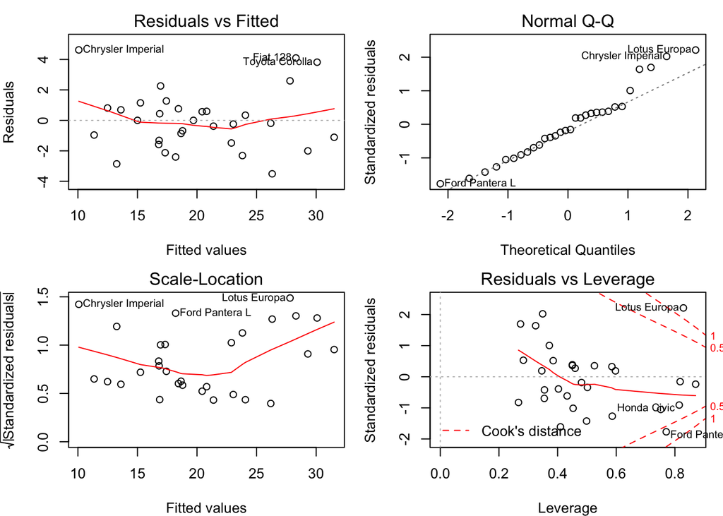

```r
par(mfrow = c(2,2), mar = c(4,4,2,1))
plot(fit_m)
```

All-subsets regression Plot

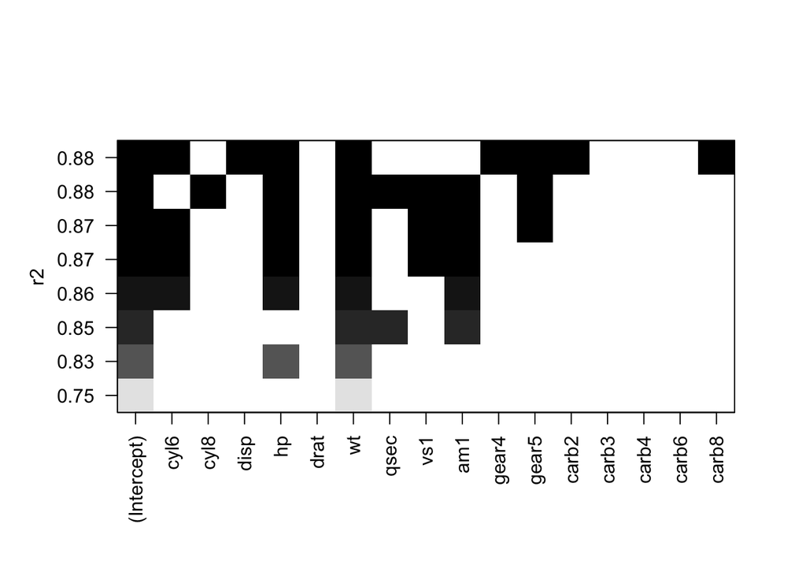

```r
par(mfrow = c(1,1), mar = c(4,4,2,1))
plot(fit_subsets, scale="r2")
```